# Data Products Assignment

Marcelo Nardelli

24/02/2020

# Introduction

This is a slidify presentation for the “Developing Data Products” assignment on week 4. It makes reference to a shiny application developed as part of the assignment. This application user a dataset of airbnb listings in the city of New York and shows two example plots that can be generated using this data. The application can be accessed at https://ganzah.shinyapps.io/DataProductsAssigment/ . Source code for the app and this presentation can be found on github, at https://github.com/ganzah/DataProductsWeek4

The airbnb dataset is loaded, preprocessed (NA’s are replaced by zeros, listings with outlier prices are removed and only certain columns are select) and two plots are presented: a boxplot of listings prices by neighbourhood group and a boxplot of prices by neighbourhood group and room type.

# Data loading and preprocessing

```r
library(dplyr); library(ggplot2); library(gridExtra); set.seed(20200224)
data <- read.csv("AB_NYC_2019.csv")
data <- data %>% as_tibble() %>%
    select(neighbourhood, neighbourhood_group, room_type, price, number_of_reviews, reviews_per_month) %>%
    replace(., is.na(.), 0) %>% filter(price > 0) %>% filter(price <= quantile(data$price, .9))
glimpse(data)
```

```
## Observations: 44,006
## Variables: 6
## $ neighbourhood       <fct> Kensington, Midtown, Harlem, Clinton Hill, East...
## $ neighbourhood_group <fct> Brooklyn, Manhattan, Manhattan, Brooklyn, Manha...
## $ room_type           <fct> Private room, Entire home/apt, Private room, En...
## $ price               <int> 149, 225, 150, 89, 80, 200, 60, 79, 79, 150, 13...
## $ number_of_reviews   <int> 9, 45, 0, 270, 9, 74, 49, 430, 118, 160, 53, 18...
## $ reviews_per_month   <dbl> 0.21, 0.38, 0.00, 4.64, 0.10, 0.59, 0.40, 3.47,...
```

```r
head(data)
```

```
## # A tibble: 6 x 6
##   neighbourhood neighbourhood_g~ room_type price number_of_revie~
##   <fct>         <fct>            <fct>     <int>            <int>
## 1 Kensington    Brooklyn         Private ~   149                9
## 2 Midtown       Manhattan        Entire h~   225               45
## 3 Harlem        Manhattan        Private ~   150                0
## 4 Clinton Hill  Brooklyn         Entire h~    89              270
## 5 East Harlem   Manhattan        Entire h~    80                9
## 6 Murray Hill   Manhattan        Entire h~   200               74
## # ... with 1 more variable: reviews_per_month <dbl>
```

# Boxplot of listings prices by neighbourhood group

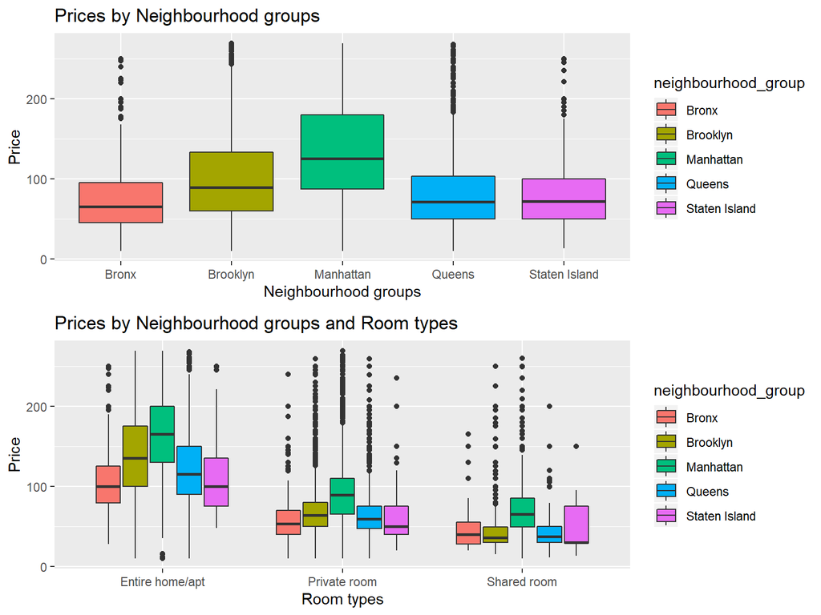

```r
newData <- data %>% filter(neighbourhood_group %in% c("Bronx", "Brooklyn", "Manhattan", "Queens", "Staten Island"))
plot1 <- ggplot(data = newData, aes(x = neighbourhood_group, y = price, fill=neighbourhood_group)) +
  geom_boxplot() +
  labs(title = "Prices by Neighbourhood groups", x = "Neighbourhood groups", y = "Price")
plot2 <- ggplot(newData, aes(x = room_type, y = price, fill=neighbourhood_group)) + geom_boxplot() +
  labs(title = "Prices by Neighbourhood groups and Room types", x = "Room types", y = "Price")
grid.arrange(plot1, plot2)
```

# Conclusion

The app shows some basic visualizations that can be achieved using the dataset. It showcases both reactive and non-reactive outputs. It also performs preprocessing that results in a dataset that could be used for other purposes (predicting prices, for example)